# Making Maps in R

Matthew L. Sisk

Last Updated November, 2021

## Loading Spatial Data

Loading spatial data in R is relatively simple, but like many things in R you have multiple options. Until recently, most spatial data in R was handled using the *sp* package to represent the different types of spatial data. There is now an additional option: the *sf* package, which is designed to be tidyverse complaint and more directly human readable. This document focuses on mapping simple maps and analysis in *sp* because it has a more robust tool library and remains slightly better documented. However, I also provide an additional document that shows most of these examples in the *sf* packages because it is quickly becoming the more dominant model.

To start with *sp*. First, the best package to use for incorporating spatial information is rgdal. This package is R bindings for the Geospatial Data Abstraction Library, which is the basis for most open-source GIS packages. This is what we will use for opening pre-existing spatial data in the form of shapefiles

```r
library(rgdal)
```

In rgdal, there are two different tools for opening raster and vector data. readOGR is the command for loading vector data. This package is based on the *sp* model and loads that package as well.

RGDAL is a little different than other read commands in r in that is wants the path (called the dsn) separate from the filename

```r
districts <- readOGR(dsn="SampleData", layer = "City_Council_Districts", stringsAsFactors = FALSE)
```

```r
head(districts@data)
```

```
##   OBJECTID_1 OBJECTID Dist Num Shape_STAr Shape_STLe       Council_Me
## 0          1        1 1301   1  379032687  212828.81        Tim Scott
## 1          2        2 1302   2  155180576   86467.59  Regina Williams
## 2          3        3 1303   3  105038775   58495.78   Sharon McBride
## 3          4        4 1304   4  132928325   84386.30     Jo M. Broden
## 4          6        5 1305   5  178901964   88467.09 Dr. David Varner
## 5       1211        6 1306   6  178901964   88467.09     Oliver Davis
##                      Email created_us               created_da last_edite
## 0   tscott@southbendin.gov       <NA>                     <NA>   JLANKOWI
## 1 rpreston@southbendin.gov       <NA>                     <NA>   JLANKOWI
## 2 smcbride@southbendin.gov       <NA>                     <NA>   JLANKOWI
## 3  jbroden@southbendin.gov       <NA>                     <NA>   JLANKOWI
## 4  dvarner@southbendin.gov       <NA>                     <NA>   JLANKOWI
## 5   odavis@southbendin.gov     DKUEHN 2016-02-25T18:25:39.000Z   JLANKOWI
##                 last_edi_1 ShapeSTAre ShapeSTLen
## 0 2016-03-30T20:49:43.000Z  378983182  211071.75
## 1 2016-03-30T20:49:48.000Z  155301226   86654.17
## 2 2018-04-10T11:47:12.000Z  104981675   61819.20
## 3 2016-03-30T20:49:59.000Z  132204336   84693.02
## 4 2016-03-30T20:50:35.000Z  211071250  161022.67
## 5 2016-03-30T20:50:29.000Z  179311920   90456.90
```

and the points that make up the polygon (and a lot more information) using the @polygons call (or @points, or @lines if it was another type of vector data). Since just displaying this would give a whole lot of numbers, you can also call the coordinates function to get a summary

```r
# (districts@polygons[[1]])
coordinates(districts[1])
```

```
##        [,1]     [,2]
## 0 -86.30431 41.71629
## 1 -86.28164 41.67689
## 2 -86.22322 41.66227
## 3 -86.22353 41.68661
## 4 -86.23254 41.62632
## 5 -86.28356 41.65417
```

### Loading spatial data from a table

Often, you will not get spatial data as part of an existing shapefile. You may instead get a table with latitude and longitude coordinates (Or street addresses, which we will get to in a different demonstration). Hear, let’s load a table that has latitude and longitude coordinates

```r
facilities.points <- read.csv("SampleData/Public_Facilities.csv")
```

Now, in order to covert this into something we can map, we to define it as a SpatialPointsDataFrame. The arguments are basically, the coodinates, the rest of the data and what coordinate system it uses. The one listed here is for latitude and longitude and is the most common you will use.

```r
facilities.spatial <- SpatialPointsDataFrame(coords = facilities.points[,c("Lon","Lat")], data = facilities.points,
                             proj4string = CRS("+proj=longlat +datum=WGS84"))
```

This now converts it over the a spatialPointsDataFrame

## Creating Static Maps

Once we have spatial data loaded in R, we can create maps easily. We can just use the base R plot to create one, but this is pretty basic

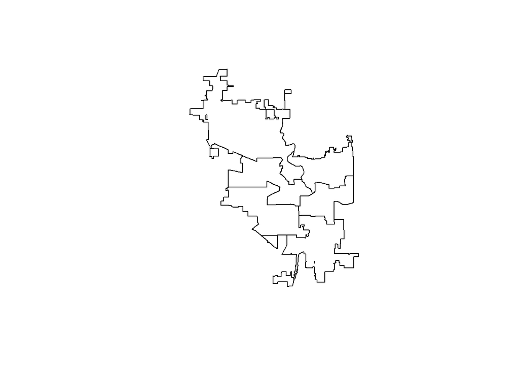

```r
plot(districts)
```

Alternatively, there are a few packages built for creating maps in R. Probably the most commonly use is ggmap, which is designed to be like ggplot for spatial data. The difficulty in using ggmap is that it only accepts a dataframe as an input, so we have to convert our hard earned SpatialDataFrames back to normal dataframes using the fortify command and then join all of the attributes back on.

```r
library(ggmap)
```

We can now use the same sort of syntax we would with a normal ggplot to create maps.

The coord_fixed just prevents the map from becoming distorted if we resize the window. It is a good idea to keep it there.

```r
districts2 <- fortify(districts, region = 'Dist')
```

```
## SpP is invalid
```

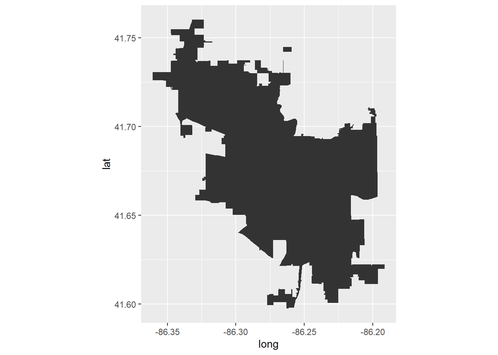

```r
districts2  <- merge(districts2, districts@data, by.x = 'id', by.y = 'Dist')

ggplot() + geom_polygon(data = districts2, aes(x=long, y = lat, group = group)) +
  coord_fixed(1.3)
```

We can now color the map based of off the district.

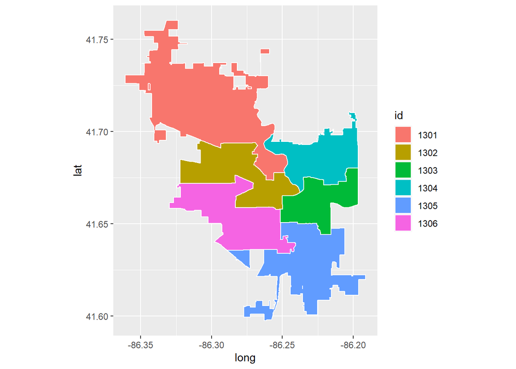

```r
ggplot(data = districts2) + geom_polygon(aes(x = long, y = lat, fill = id, group = group), color = "white") +
  coord_fixed(1.3)
```

We can now add other layers just like we would in normal ggplot

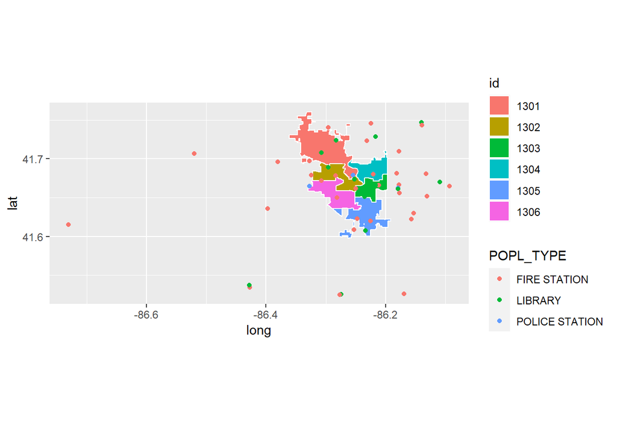

```r
ggplot(data = districts2) + geom_polygon(aes(x = long, y = lat, fill = id, group = group), color = "white") +
  coord_fixed(1.3)+
  geom_point(data = facilities.points, aes(x = Lon, y = Lat, group = POPL_TYPE, col = POPL_TYPE))
```

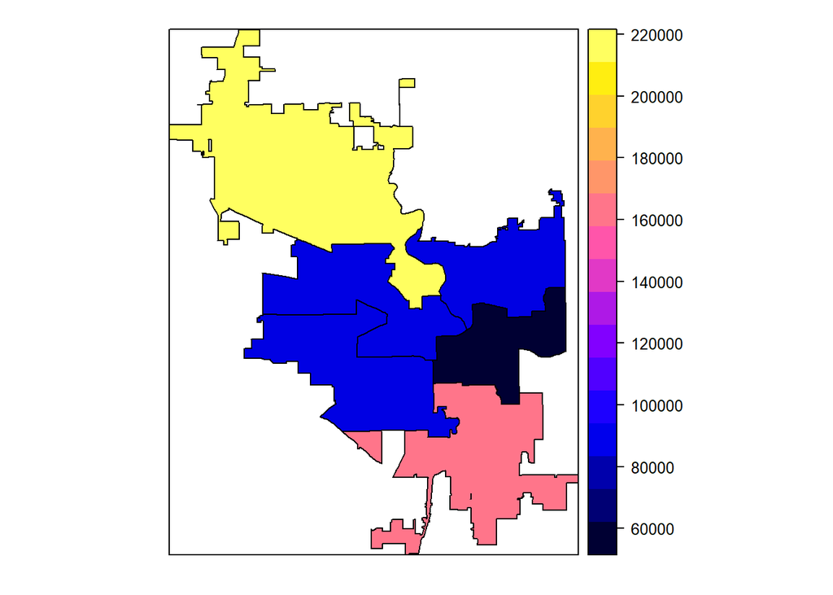

```r
spplot(districts, "ShapeSTLen")
```

[figure not shown]

```r
# register_google(key = "YOUR_KEY_HERE")

base.map <- get_map("South Bend, IN", zoom = 12, maptype = "roadmap")
base.map <-  get_stamenmap( bbox = c(left = -86.36, bottom = 41.59, right = -86.14,top = 41.76), zoom = 12)
ggmap(base.map)+
  geom_point(data = facilities.points, aes(x = Lon, y = Lat, group = POPL_TYPE, col = POPL_TYPE))
```